# By way of introduction…

# Anatomy of `aes()`

```r
# NOT run
ggplot(data = , aes(x = , y = , color = , linetype = , shape = , size = ))
```

These four aesthetic parameters (`color`, `linetype`, `shape`, `size`) can be used to show variation in *kind* (categories) and variation in *degree* (numeric).

Parameters passed into `aes` should be *variables* in your dataset.

Parameters passed to `geom_xxx` outside of `aes` should *not* be related to your dataset – they apply to the whole figure.

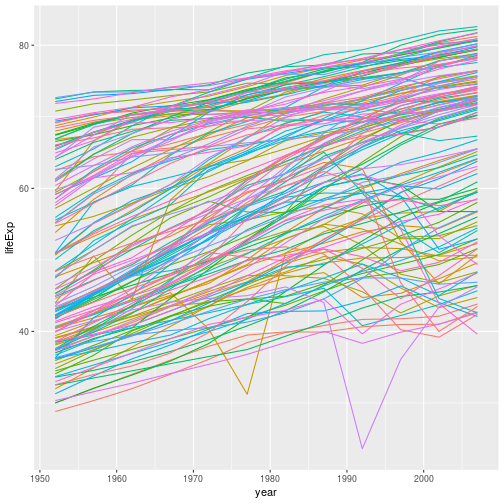

```r
ggplot(data = gap, aes(x = year, y = lifeExp)) +
            geom_line(aes(color = country), show.legend = FALSE)
```

Note what happens when we specify the color parameter outside of the aesthetic operator. `ggplot2` views these specifications as invalid graphical parameters.

```r
ggplot(data = gap, aes(x = year, y = lifeExp)) +
            geom_line(color = country)
```

```
## Error in layer(data = data, mapping = mapping, stat = stat, geom = GeomLine, : object 'country' not found
```

```r
ggplot(data = gap, aes(x = year, y = lifeExp)) +
            geom_line(color = "country")
```

```
## Error in grDevices::col2rgb(colour, TRUE): invalid color name 'country'
```

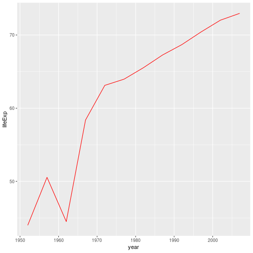

```r
## this works but only makes sense if we restrict to one country
ggplot(data = gapChina, aes(x = year, y = lifeExp)) +
            geom_line(color = "red")
```

**Note:** Aesthetics automatically show up in your legend, parameters (those not mapped to a variable in your data frame) do not!

# Using aesthetics to highlight features

Differences in kind

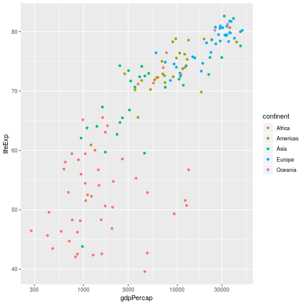

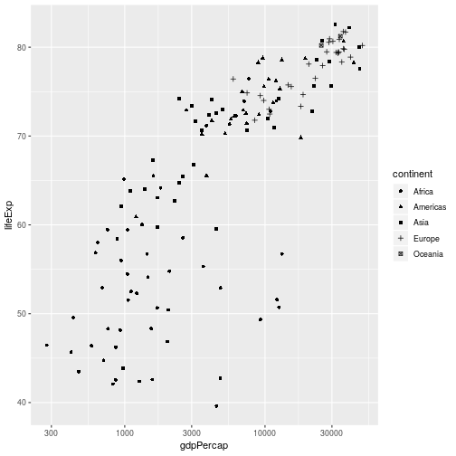

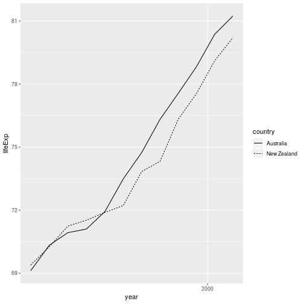

```r
## color as the aesthetic to differentiate by continent
ggplot(data = gap2007, aes(x = gdpPercap, y = lifeExp)) +
            geom_point(aes(color = continent)) + scale_x_log10()

## point shape as the aesthetic to differentiate by continent
ggplot(data = gap2007, aes(x = gdpPercap, y = lifeExp)) +
            geom_point(aes(shape = continent)) + scale_x_log10()

## line type as the aesthetic to differentiate by country
gapOceania <- gap %>% filter(continent %in% 'Oceania')
ggplot(data = gapOceania, aes(x = year, y = lifeExp)) +
            geom_line(aes(linetype = country)) + scale_x_log10()
```

Differences in degree

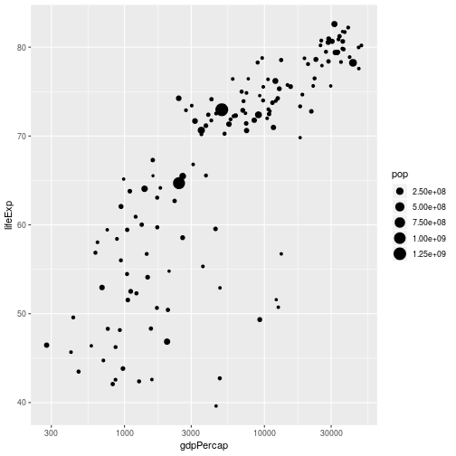

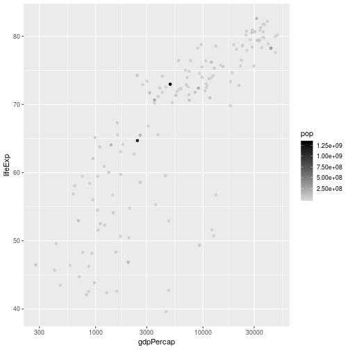

```r
## point size as the aesthetic to differentiate by population
ggplot(data = gap2007, aes(x = gdpPercap, y = lifeExp)) +
            geom_point(aes(size = pop)) + scale_x_log10()

## color as the aesthetic to differentiate by population
ggplot(data = gap2007, aes(x = gdpPercap, y = lifeExp)) +
            geom_point(aes(color = pop)) + scale_x_log10() +
            scale_color_gradient(low = 'lightgray', high = 'black')
```

Multiple non-coordinate aesthetics (differences in kind using color, degree using point size)

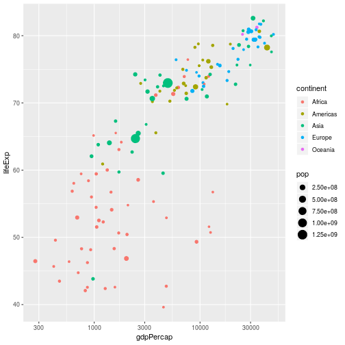

```r
ggplot(data = gap2007, aes(x = gdpPercap, y = lifeExp)) +
            geom_point(aes(size = pop, color = continent)) + scale_x_log10()
```

### Scaling Aesthetics:

Aesthetics are handled by their very own `scale` functions which allow you to set the limits, breaks, tranformations, and any palletes that might determine how you want your data plotted. `ggplot2` includes a number of helpful default scale functions like `scale_x_log10` that can tranform your data on the fly or `scale_color_viridis` which uses palettes from the `viridis` package specifically designed to “make plots that are pretty, better represent your data, easier to read by those with colorblindness, and print well in grey scale.”

For example, our data might be better represented using a log10 transformation of per capita GDP:

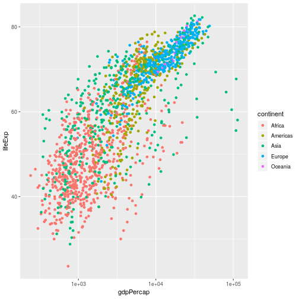

```r
ggplot(gap, aes(x = gdpPercap, y = lifeExp)) +
            geom_point(aes(color = continent)) +
  scale_x_log10()
```

And perhaps we want colors that are a little different:

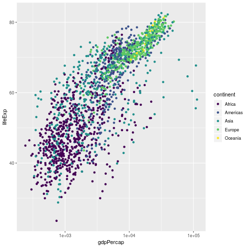

```r
ggplot(gap, aes(x = gdpPercap, y = lifeExp)) +
            geom_point(aes(color = continent)) +
  scale_x_log10() +
  scale_color_viridis_d()
```

Or perhaps we want to set your palettes and breaks or labels manually:

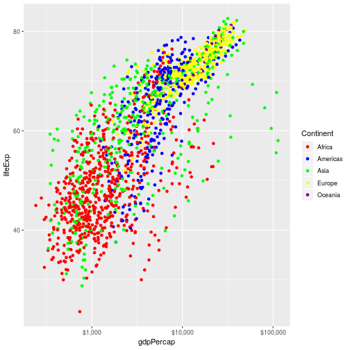

```r
ggplot(gap, aes(x = gdpPercap, y = lifeExp)) +
            geom_point(aes(color = continent)) +
  scale_x_log10(labels = scales::dollar) +
  scale_color_manual("Continent",
                     values = c("red", "blue", "green", "yellow", "#800080")) # hex codes work!
```

For more info about setting scales in `ggplot2` and for more helper functions consider diving into the `scales` package which is the backend to much of the scales functionality in `ggplot2`

# Fine tuning your plot

`ggplot` handles many plot options as additional layers.

### Labels

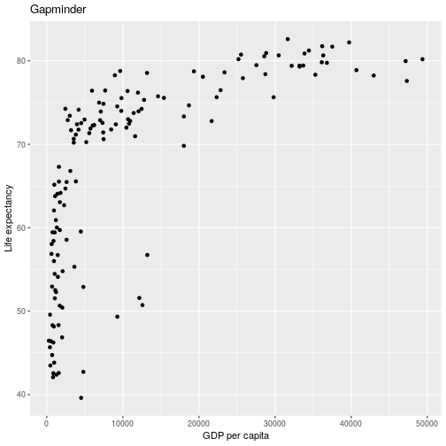

```r
ggplot(data = gap2007, aes(x = gdpPercap, y = lifeExp)) + geom_point() +
  xlab(label = "GDP per capita") +
  ylab(label = "Life expectancy") +
  ggtitle(label = "Gapminder")
```

Or even more simply use the `labs()` function

```r
ggplot(data = gap2007, aes(x = gdpPercap, y = lifeExp)) + geom_point() +
  labs(x = "GDP per capita", y = "Life expectancy", title = "Gapminder")
```

### Axis and point scales

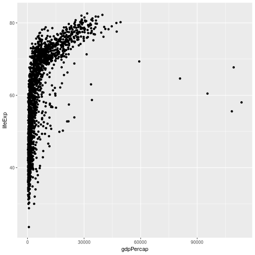

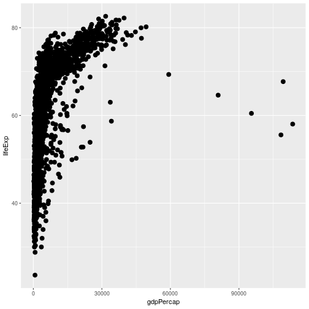

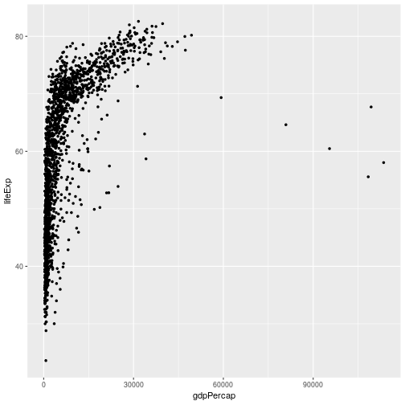

```r
ggplot(data = gap, aes(x = gdpPercap, y = lifeExp)) +
            geom_point()
ggplot(data = gap, aes(x = gdpPercap, y = lifeExp)) +
            geom_point(size=3)
ggplot(data = gap, aes(x = gdpPercap, y = lifeExp)) +
            geom_point(size=1)
```

### Colors

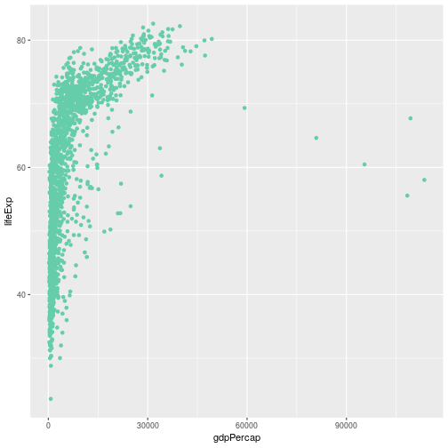

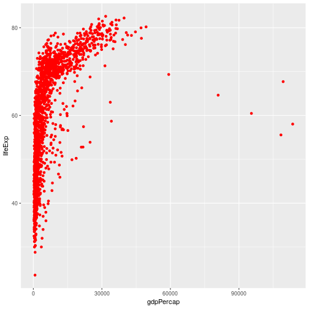

```r
ggplot(data = gap, aes(x = gdpPercap, y = lifeExp)) +
            geom_point(color = colors()[11])
ggplot(data = gap, aes(x = gdpPercap, y = lifeExp)) +
            geom_point(color = "red")
```

### Point Styles and Widths

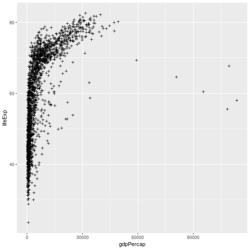

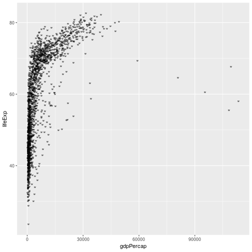

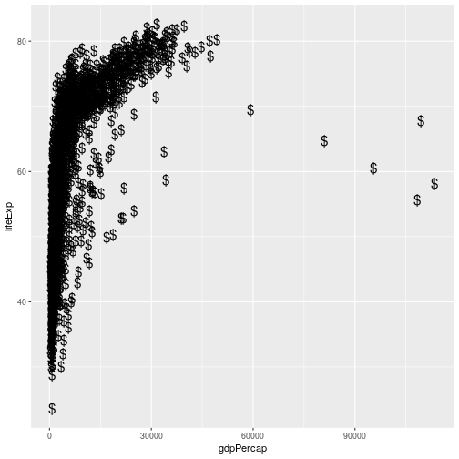

```r
ggplot(data = gap, aes(x = gdpPercap, y = lifeExp)) +
            geom_point(shape = 3)
ggplot(data = gap, aes(x = gdpPercap, y = lifeExp)) +
            geom_point(shape = "w")
ggplot(data = gap, aes(x = gdpPercap, y = lifeExp)) +
            geom_point(shape = "$", size=5)
```

### Line Styles and Widths

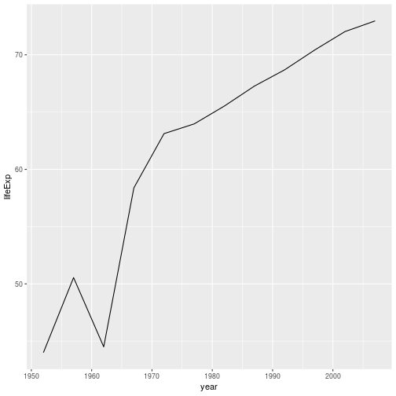

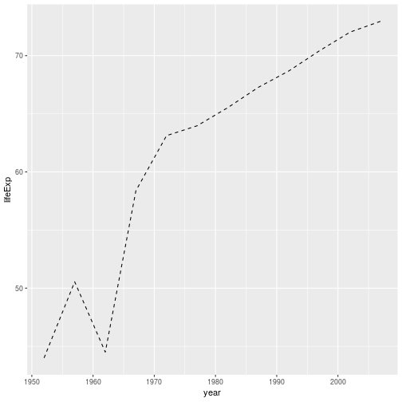

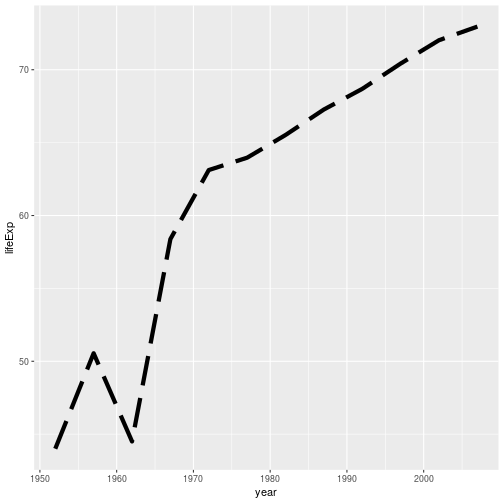

```r
ggplot(data = gapChina, aes(x = year, y = lifeExp)) +
            geom_line(linetype = 1)
ggplot(data = gapChina, aes(x = year, y = lifeExp)) +
            geom_line(linetype = 2)
ggplot(data = gapChina, aes(x = year, y = lifeExp)) +
            geom_line(linetype = 5, size = 2)
```

### Themes with `ggplot2`

Elements of the plot *not associated with geometries* can be adjusted using ggplot *themes*.

There are some “complete” themes already included with the package:

- `theme_gray()` (the default)
- `theme_minimal()`
- `theme_bw()`
- `theme_light()`
- `theme_dark()`
- `theme_classic()`

But in additional to these, you can tweak just about any element of your plot's appearance using the `theme()` function.

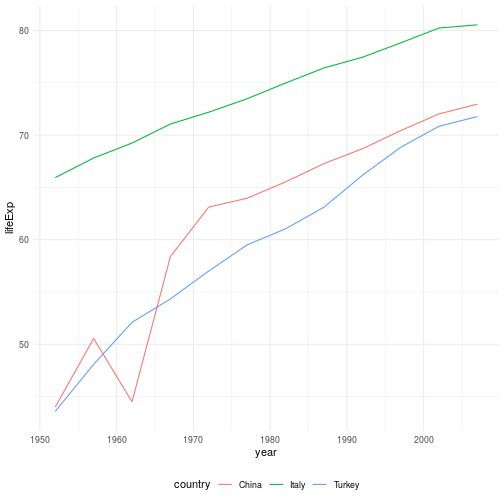

```r
gap %>%
  filter(country %in% c("China", "Turkey", "Italy")) %>%
  ggplot(aes(x = year, y = lifeExp)) +
  geom_line(aes(color = country)) +
  theme_minimal() +
  theme(legend.position = "bottom")
```

- In the future, geom aesthetics [may even be themeable…](https://github.com/tidyverse/ggplot2/pull/2749)!

# Combining Multiple Plots

- `ggplot2` graphs can be combined using the *`grid.arrange()`* function in the **`gridExtra`** package

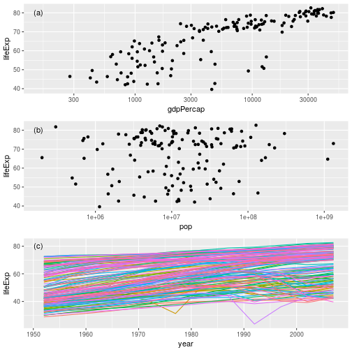

```r
# Initialize gridExtra library
library(gridExtra)

# Create 3 plots to combine in a table
plot1 <- ggplot(data = gap2007, aes(x = gdpPercap, y = lifeExp)) +
  geom_point() + scale_x_log10() + annotate('text', 150, 80, label = '(a)')
plot2 <- ggplot(data = gap2007, aes(x = pop, y = lifeExp)) +
  geom_point() + scale_x_log10() + annotate('text', 1.8e5, 80, label = '(b)')
plot3 <- ggplot(data = gap, aes(x = year, y = lifeExp)) +
      geom_line(aes(color = country), show.legend = FALSE) +
      annotate('text', 1951, 80, label = '(c)')


# Call grid.arrange
grid.arrange(plot1, plot2, plot3, nrow=3, ncol = 1)
```

# `patchwork`: Combining Multiple `ggplot2` plots

- The `patchwork` package may be used to combine multiple `ggplot2` plots using a small set of operators similar to the pipe.
- This requires less syntax than using `gridExtra` and allows complex arrangements to be built nearly effortlessly.

```r
# Install and initialize patchwork library
# devtools::install_github("thomasp85/patchwork")
library(patchwork)
```

[output not shown]

```r
# use the patchwork operators
# stack plots horizontally
plot1 + plot2 + plot3
```

[output not shown]

```r
# stack plots vertically
plot1 / plot2 / plot3
```

[output not shown]

```r
# side-by-side plots with third plot below
(plot1 | plot2) / plot3
```

[output not shown]

```r
# side-by-side plots with a space in between, and a third plot below
(plot1 | plot_spacer() | plot2) / plot3
```

[output not shown]

```r
# stack plots vertically and alter with a single "gg_theme"
(plot1 / plot2 / plot3) & theme_bw()
```

[output not shown]

Feel free to explore more at https://github.com/thomasp85/patchwork.

**Note:** `patchwork` is an example of a ggplot2 extension package of which there are many! One of the benefits to learning and using `ggplot2` is that there is a huge community of developers that build separate graphics packages that generally use the same syntax to extend the `ggplot2` functionality into things like animation and 3D plotting! Check them out –> http://www.ggplot2-exts.org/gallery/

# Exporting

Two basic image types:

### **Raster/Bitmap** (.png, .jpeg)

Every pixel of a plot contains its own separate coding; not so great if you want to resize the image

```r
jpeg(filename = "example.jpg", width=, height=)
plot(x,y)
dev.off()
```

### **Vector** (.pdf, .ps)

Every element of a plot is encoded with a function that gives its coding conditional on several factors; great for resizing

```r
# NOT run
pdf(file = "example.pdf", width=, height=)
plot(x,y)
dev.off()
```

### Exporting with `ggplot`

```r
# NOT run

# Assume we saved our plot is an object called `plot1`.

ggsave(filename = "example.pdf", plot = plot1, scale = , width = ,
       height = )
```

# Breakout

Please fill out the feedback survey.

https://berkeley.qualtrics.com/jfe/form/SV_0Jy1rtGhm3a7lHf

# Breakout

These questions ask you to work with the gapminder dataset.

### Basics

1) Plot a histogram of life expectancy.

2) Plot the gdp per capita against population. Put the x-axis on the log scale.

3) Clean up your scatterplot with a title and axis labels. Output it as a PDF and see if you'd be comfortable with including it in a report/paper.

### Using the ideas

4) Create a trellis plot of life expectancy by gdpPercap scatterplots, one subplot per continent. Use a 2x3 layout of panels in the plot. Now have the size of the points vary with population. Use `scale_x_continuous()` to set the x-axis limits to be in the range from 100 to 50000.

5) Make a boxplot of life expectancy conditional on binned values of gdp per capita.

### Advanced

6) Using the data for 2007, recreate as much as you can of [this famous Gapminder plot](https://s3-eu-west-1.amazonaws.com/static.gapminder.org/GapminderMedia/wp-uploads/20161019161829/screenshot2016.jpg), where the colors are different continents. (Don't worry about the '2015' in the background and ignore the 'play' button at the bottom.)

7) Create a “trellis” plot where, for a given year, each panel uses a) hollow circles to plot lifeExp as a function of log(gdpPercap), and b) a red loess smoother without standard errors to plot the trend. Turn off the grey background. Figure out how to use partially-transparent points to reduce the effect of the overplotting of points.